# Estadística descriptiva con datos ordinales

Ramon Ceballos

29/1/2021

# 1. Tablas multidimensionales para datos ordinales

Para calcular frecuencias acumuladas en una tabla multidimensional, hay que aplicar a la tabla la función **`cumsum`** mediante la función **`apply`** que ya explicábamos para matrices. En este caso en concreto, la sintaxis de la instrucción sería: **`apply(tabla, MARGIN = ..., FUN = cumsum)`**

En esta expresión, el valor **`MARGIN`** ha de ser el de la dimensión en la que queremos acumular las frecuencias: 1 si queremos hacerlo por filas, 2 para hacerlo por columnas (tambíén se podría hacer para una tercera variable y más). Lo veremos todo más claro con un ejemplo.

### Ejemplo 1

Se ha evaluado el tamaño de los cuellos de 100 jirafas. Los niveles que se han utilizado se los considera ordenados de la siguiente manera:

$$\text{Muy.corto}<\text{Corto}<\text{Normal}<\text{Largo}<\text{Muy.largo}$$

Los valores obtenidos en dicho estudio han sido los siguientes:

```r
set.seed(2018)

longitud = sample(1:5,100, replace = TRUE)

longitud = ordered(longitud)

levels(longitud) = c("Muy.corto","Corto","Normal","Largo","Muy.largo")
```

```r
#vector a estudiar del cuello de las jirafas
longitud
```

```
##   [1] Normal    Largo     Muy.largo Corto     Muy.largo Muy.corto Normal
##   [8] Largo     Corto     Largo     Normal    Normal    Muy.corto Muy.corto
##  [15] Muy.largo Normal    Muy.corto Normal    Normal    Muy.largo Muy.corto
##  [22] Largo     Corto     Muy.largo Normal    Largo     Muy.largo Muy.corto
##  [29] Corto     Corto     Muy.corto Muy.largo Muy.largo Corto     Muy.corto
##  [36] Corto     Muy.largo Muy.largo Corto     Muy.corto Corto     Muy.corto
##  [43] Normal    Corto     Muy.corto Corto     Normal    Normal    Muy.corto
##  [50] Corto     Normal    Muy.corto Largo     Largo     Corto     Muy.corto
##  [57] Corto     Normal    Normal    Normal    Normal    Muy.corto Normal
##  [64] Muy.corto Corto     Largo     Muy.corto Corto     Muy.corto Muy.largo
##  [71] Muy.corto Corto     Muy.largo Largo     Muy.largo Normal    Corto
##  [78] Corto     Normal    Largo     Largo     Corto     Corto     Muy.largo
##  [85] Largo     Largo     Normal    Normal    Muy.corto Normal    Corto
##  [92] Normal    Muy.corto Corto     Muy.corto Normal    Corto     Corto
##  [99] Muy.corto Corto
## Levels: Muy.corto < Corto < Normal < Largo < Muy.largo
```

Supongamos que en el ejemplo anterior, el de las jirafas, estas provienen de 4 zonas diferentes (A, B, C y D), de manera que las 30 primeras son de la zona A, las 25 siguientes de la B, las 35 siguientes de la C y las 10 últimas de la D. Nos interesa estudiar la distribución de las longitudes según la zona.

Vamos a organizar todos estos datos en un data frame llamado **`jirafas`**. Para que nos sea más fácil visualizar la información, es conveniente que las filas de las tablas de frecuencias correspondan a las zonas. Por lo tanto, al definir el data frame, entraremos como primera variable la de la muestra las zonas. Así, conseguiremos que éstas aparezcan en las filas al aplicarle la función **table()**.

```r
#se define el array de zonas (no es un vector ordenado)
zonas = rep(c("A","B","C","D"), c(30,25,35,10))

#configuramos el DF jirafas
jirafas = data.frame(zonas,longitud)

#Se disciernen dos variabless, siendo:
# - Un factor sin ordenar.
# - Un factor ordenado.
str(jirafas)
```

```
## 'data.frame':    100 obs. of  2 variables:
##  $ zonas   : Factor w/ 4 levels "A","B","C","D": 1 1 1 1 1 1 1 1 1 1 ...
##  $ longitud: Ord.factor w/ 5 levels "Muy.corto"<"Corto"<..: 3 4 5 2 5 1 3 4 2 4 ...
```

```r
head(jirafas,4)
```

|  | zonas | longitud |
| --- | --- | --- |
| 1 | A | Normal |
| 2 | A | Largo |
| 3 | A | Muy.largo |
| 4 | A | Corto |

**Tabla de frecuencias absolutas**

Para calcular la tabla de frecuencias absolutas acumuladas de las longitudes por zonas y como las zonas definen las filas de la tabla anterior, debemos utilizar la función **`apply`** con **`MARGIN = 1`**.

```r
#Se generan las frecuencias acumuladas por zonas (A,B,C,D)
apply(table(jirafas), MARGIN = 1, FUN = cumsum)
```

```
##            zonas
## longitud     A  B  C  D
##   Muy.corto  6  7  7  3
##   Corto     11 15 15  8
##   Normal    19 19 25 10
##   Largo     24 21 31 10
##   Muy.largo 30 25 35 10
```

Fijaos que la tabla se ha traspuesto la fila y la columna. Resulta que cuando se aplica **`apply`** a una **`table`** bidimensional, R intercambia, en caso de ser necesario, filas por columnas en el resultado para que la dimensión de la tabla resultante en la que se haya aplicado la función sea la de las columnas.

Con lo cual, para volver a tener las zonas en las filas, hay que **trasponer el resultado de la función `apply`**.

```r
#transpuesta de la tabla que genera las frecuencias acumuladas por zonas
t(apply(table(jirafas), MARGIN = 1, FUN = cumsum))
```

```
##      longitud
## zonas Muy.corto Corto Normal Largo Muy.largo
##     A         6    11     19    24        30
##     B         7    15     19    21        25
##     C         7    15     25    31        35
##     D         3     8     10    10        10
```

**Tabla de frecuencias relativas acumuladas**

Vamos ahora a calcular la tabla de frecuencias relativas acumuladas de las longitudes de cuello por zonas. Para conseguirlo, y en una única instrucción, primero calculamos la tabla de *frecuencias relativas por filas*, a continuación, con las funciones **`apply`** y **`cumsum`** las acumulamos y, finalmente, trasponemos el resultado.

```r
#Obtenemos la tabla de frecuecnias acumuladas por filas (zonas)
t(apply(prop.table(table(jirafas), margin = 1), MARGIN = 1, FUN = cumsum))
```

```
##      longitud
## zonas Muy.corto     Corto    Normal     Largo Muy.largo
##     A      0.20 0.3666667 0.6333333 0.8000000         1
##     B      0.28 0.6000000 0.7600000 0.8400000         1
##     C      0.20 0.4285714 0.7142857 0.8857143         1
##     D      0.30 0.8000000 1.0000000 1.0000000         1
```

**Diagrama de Barras por bloques**

Vamos ahora a dibujar el diagrama de barras por bloques de esta tabla. Nos interesa que las barras de este diagrama se agrupen por zonas. Entonces, tendremos que aplicar **`barplot`** a la tabla sin trasponer.

Además, vamos a colocar la leyenda en la esquina superior izquierda para que no se superponga a ninguna barra. También reduciremos el tamaño del texto de la leyenda para que quepa completamente.

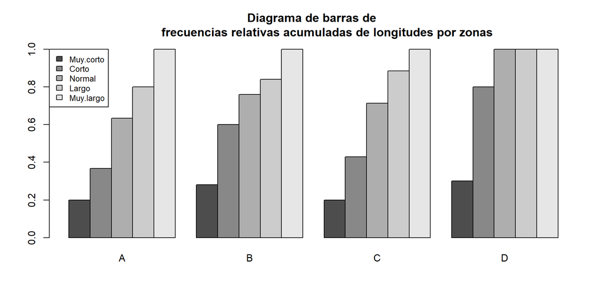

```r
Diagrama = apply(prop.table(table(jirafas), margin = 1), MARGIN = 1, FUN = cumsum)

barplot(Diagrama,
        beside = TRUE,
        legend = TRUE,
        main = "Diagrama de barras de
        frecuencias relativas acumuladas de longitudes por zonas",
        args.legend=list(x="topleft", cex=0.8))
```

Se ha representado con las frecuencias relativas acumuladas en vez de las absolutas, para poder comparar las zonas con mayor facilidad.

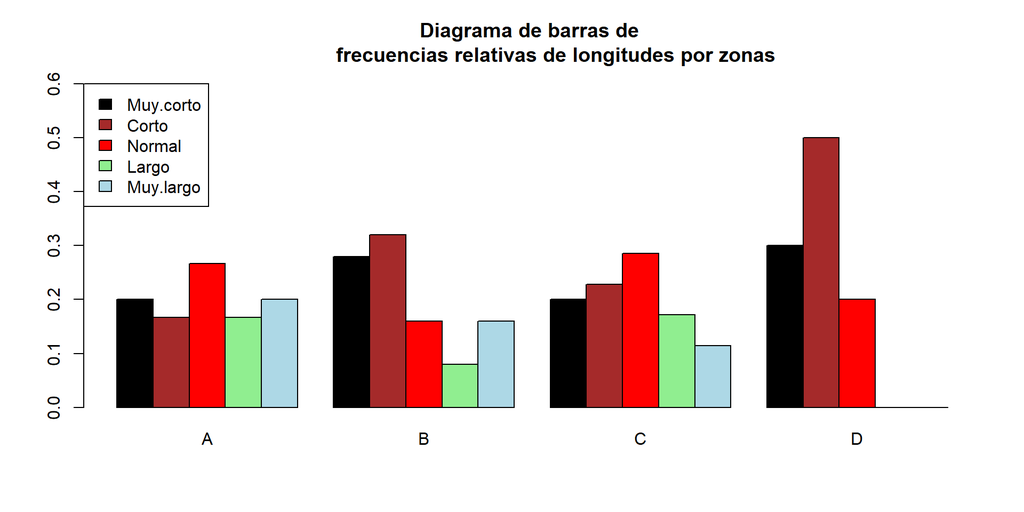

```r
Diagrama2 = t(prop.table(table(jirafas), margin = 1))

barplot(Diagrama2,
        beside = TRUE,
        legend = TRUE,
        main = "Diagrama de barras de
        frecuencias relativas de longitudes por zonas",
        args.legend=list(x="topleft", cex=1),
        col=c("black","brown","red","lightgreen","lightblue"),
        ylim=c(0,0.6))
```